# GRADS

EAARNINGS BASED ON COLLEGE MAJORS

working with a dataset on the job outcomes of students who graduated from college between 2010 and 2012. The original data on job outcomes was released by American Community Survey, which conducts surveys and aggregates the data. FiveThirtyEight cleaned the dataset and released it on their Github repo.

Each row in the dataset represents a different major in college and contains information on gender diversity, employment rates, median salaries, and more. Here are some of the columns in the dataset:

- Rank - Rank by median earnings (the dataset is ordered by this column).
- Major_code - Major code.
- Major - Major description.
- Major_category - Category of major.
- Total - Total number of people with major.
- Sample_size - Sample size (unweighted) of full-time.
- Men - Male graduates.
- Women - Female graduates.
- ShareWomen - Women as share of total.
- Employed - Number employed.
- Median - Median salary of full-time, year-round workers.
- Low_wage_jobs - Number in low-wage service jobs.
- Full_time - Number employed 35 hours or more.
- Part_time - Number employed less than 35 hours.

Do students in more popular majors make more money?

- Using scatter plots How many majors are predominantly male? Predominantly female?
- Using histograms Which category of majors have the most students?
- Using bar plots

```python
import pandas as pd
import matplotlib.pyplot as plt
```

```python
%matplotlib inline
```

```python
recent_grads = pd.read_csv('recent-grads.csv', encoding = 'UTF-8')
```

```python
recent_grads
```

|  | Rank | Major_code | Major | Total | Men | Women | Major_category | ShareWomen | Sample_size | Employed | ... | Part_time | Full_time_year_round | Unemployed | Unemployment_rate | Median | P25th | P75th | College_jobs | Non_college_jobs | Low_wage_jobs |
| --- | --- | --- | --- | --- | --- | --- | --- | --- | --- | --- | --- | --- | --- | --- | --- | --- | --- | --- | --- | --- | --- |
| 0 | 1 | 2419 | PETROLEUM ENGINEERING | 2339.0 | 2057.0 | 282.0 | Engineering | 0.120564 | 36 | 1976 | ... | 270 | 1207 | 37 | 0.018381 | 110000 | 95000 | 125000 | 1534 | 364 | 193 |
| 1 | 2 | 2416 | MINING AND MINERAL ENGINEERING | 756.0 | 679.0 | 77.0 | Engineering | 0.101852 | 7 | 640 | ... | 170 | 388 | 85 | 0.117241 | 75000 | 55000 | 90000 | 350 | 257 | 50 |
| 2 | 3 | 2415 | METALLURGICAL ENGINEERING | 856.0 | 725.0 | 131.0 | Engineering | 0.153037 | 3 | 648 | ... | 133 | 340 | 16 | 0.024096 | 73000 | 50000 | 105000 | 456 | 176 | 0 |
| 3 | 4 | 2417 | NAVAL ARCHITECTURE AND MARINE ENGINEERING | 1258.0 | 1123.0 | 135.0 | Engineering | 0.107313 | 16 | 758 | ... | 150 | 692 | 40 | 0.050125 | 70000 | 43000 | 80000 | 529 | 102 | 0 |
| 4 | 5 | 2405 | CHEMICAL ENGINEERING | 32260.0 | 21239.0 | 11021.0 | Engineering | 0.341631 | 289 | 25694 | ... | 5180 | 16697 | 1672 | 0.061098 | 65000 | 50000 | 75000 | 18314 | 4440 | 972 |
| 5 | 6 | 2418 | NUCLEAR ENGINEERING | 2573.0 | 2200.0 | 373.0 | Engineering | 0.144967 | 17 | 1857 | ... | 264 | 1449 | 400 | 0.177226 | 65000 | 50000 | 102000 | 1142 | 657 | 244 |
| 6 | 7 | 6202 | ACTUARIAL SCIENCE | 3777.0 | 2110.0 | 1667.0 | Business | 0.441356 | 51 | 2912 | ... | 296 | 2482 | 308 | 0.095652 | 62000 | 53000 | 72000 | 1768 | 314 | 259 |
| 7 | 8 | 5001 | ASTRONOMY AND ASTROPHYSICS | 1792.0 | 832.0 | 960.0 | Physical Sciences | 0.535714 | 10 | 1526 | ... | 553 | 827 | 33 | 0.021167 | 62000 | 31500 | 109000 | 972 | 500 | 220 |
| 8 | 9 | 2414 | MECHANICAL ENGINEERING | 91227.0 | 80320.0 | 10907.0 | Engineering | 0.119559 | 1029 | 76442 | ... | 13101 | 54639 | 4650 | 0.057342 | 60000 | 48000 | 70000 | 52844 | 16384 | 3253 |
| 9 | 10 | 2408 | ELECTRICAL ENGINEERING | 81527.0 | 65511.0 | 16016.0 | Engineering | 0.196450 | 631 | 61928 | ... | 12695 | 41413 | 3895 | 0.059174 | 60000 | 45000 | 72000 | 45829 | 10874 | 3170 |
| 10 | 11 | 2407 | COMPUTER ENGINEERING | 41542.0 | 33258.0 | 8284.0 | Engineering | 0.199413 | 399 | 32506 | ... | 5146 | 23621 | 2275 | 0.065409 | 60000 | 45000 | 75000 | 23694 | 5721 | 980 |
| 11 | 12 | 2401 | AEROSPACE ENGINEERING | 15058.0 | 12953.0 | 2105.0 | Engineering | 0.139793 | 147 | 11391 | ... | 2724 | 8790 | 794 | 0.065162 | 60000 | 42000 | 70000 | 8184 | 2425 | 372 |
| 12 | 13 | 2404 | BIOMEDICAL ENGINEERING | 14955.0 | 8407.0 | 6548.0 | Engineering | 0.437847 | 79 | 10047 | ... | 2694 | 5986 | 1019 | 0.092084 | 60000 | 36000 | 70000 | 6439 | 2471 | 789 |
| 13 | 14 | 5008 | MATERIALS SCIENCE | 4279.0 | 2949.0 | 1330.0 | Engineering | 0.310820 | 22 | 3307 | ... | 878 | 1967 | 78 | 0.023043 | 60000 | 39000 | 65000 | 2626 | 391 | 81 |
| 14 | 15 | 2409 | ENGINEERING MECHANICS PHYSICS AND SCIENCE | 4321.0 | 3526.0 | 795.0 | Engineering | 0.183985 | 30 | 3608 | ... | 811 | 2004 | 23 | 0.006334 | 58000 | 25000 | 74000 | 2439 | 947 | 263 |
| 15 | 16 | 2402 | BIOLOGICAL ENGINEERING | 8925.0 | 6062.0 | 2863.0 | Engineering | 0.320784 | 55 | 6170 | ... | 1983 | 3413 | 589 | 0.087143 | 57100 | 40000 | 76000 | 3603 | 1595 | 524 |
| 16 | 17 | 2412 | INDUSTRIAL AND MANUFACTURING ENGINEERING | 18968.0 | 12453.0 | 6515.0 | Engineering | 0.343473 | 183 | 15604 | ... | 2243 | 11326 | 699 | 0.042876 | 57000 | 37900 | 67000 | 8306 | 3235 | 640 |
| 17 | 18 | 2400 | GENERAL ENGINEERING | 61152.0 | 45683.0 | 15469.0 | Engineering | 0.252960 | 425 | 44931 | ... | 7199 | 33540 | 2859 | 0.059824 | 56000 | 36000 | 69000 | 26898 | 11734 | 3192 |
| 18 | 19 | 2403 | ARCHITECTURAL ENGINEERING | 2825.0 | 1835.0 | 990.0 | Engineering | 0.350442 | 26 | 2575 | ... | 343 | 1848 | 170 | 0.061931 | 54000 | 38000 | 65000 | 1665 | 649 | 137 |
| 19 | 20 | 3201 | COURT REPORTING | 1148.0 | 877.0 | 271.0 | Law & Public Policy | 0.236063 | 14 | 930 | ... | 223 | 808 | 11 | 0.011690 | 54000 | 50000 | 54000 | 402 | 528 | 144 |
| 20 | 21 | 2102 | COMPUTER SCIENCE | 128319.0 | 99743.0 | 28576.0 | Computers & Mathematics | 0.222695 | 1196 | 102087 | ... | 18726 | 70932 | 6884 | 0.063173 | 53000 | 39000 | 70000 | 68622 | 25667 | 5144 |
| 21 | 22 | 1104 | FOOD SCIENCE | NaN | NaN | NaN | Agriculture & Natural Resources | NaN | 36 | 3149 | ... | 1121 | 1735 | 338 | 0.096931 | 53000 | 32000 | 70000 | 1183 | 1274 | 485 |
| 22 | 23 | 2502 | ELECTRICAL ENGINEERING TECHNOLOGY | 11565.0 | 8181.0 | 3384.0 | Engineering | 0.292607 | 97 | 8587 | ... | 1873 | 5681 | 824 | 0.087557 | 52000 | 35000 | 60000 | 5126 | 2686 | 696 |
| 23 | 24 | 2413 | MATERIALS ENGINEERING AND MATERIALS SCIENCE | 2993.0 | 2020.0 | 973.0 | Engineering | 0.325092 | 22 | 2449 | ... | 1040 | 1151 | 70 | 0.027789 | 52000 | 35000 | 62000 | 1911 | 305 | 70 |
| 24 | 25 | 6212 | MANAGEMENT INFORMATION SYSTEMS AND STATISTICS | 18713.0 | 13496.0 | 5217.0 | Business | 0.278790 | 278 | 16413 | ... | 2420 | 13017 | 1015 | 0.058240 | 51000 | 38000 | 60000 | 6342 | 5741 | 708 |
| 25 | 26 | 2406 | CIVIL ENGINEERING | 53153.0 | 41081.0 | 12072.0 | Engineering | 0.227118 | 565 | 43041 | ... | 10080 | 29196 | 3270 | 0.070610 | 50000 | 40000 | 60000 | 28526 | 9356 | 2899 |
| 26 | 27 | 5601 | CONSTRUCTION SERVICES | 18498.0 | 16820.0 | 1678.0 | Industrial Arts & Consumer Services | 0.090713 | 295 | 16318 | ... | 1751 | 12313 | 1042 | 0.060023 | 50000 | 36000 | 60000 | 3275 | 5351 | 703 |
| 27 | 28 | 6204 | OPERATIONS LOGISTICS AND E-COMMERCE | 11732.0 | 7921.0 | 3811.0 | Business | 0.324838 | 156 | 10027 | ... | 1183 | 7724 | 504 | 0.047859 | 50000 | 40000 | 60000 | 1466 | 3629 | 285 |
| 28 | 29 | 2499 | MISCELLANEOUS ENGINEERING | 9133.0 | 7398.0 | 1735.0 | Engineering | 0.189970 | 118 | 7428 | ... | 1662 | 5476 | 597 | 0.074393 | 50000 | 39000 | 65000 | 3445 | 2426 | 365 |
| 29 | 30 | 5402 | PUBLIC POLICY | 5978.0 | 2639.0 | 3339.0 | Law & Public Policy | 0.558548 | 55 | 4547 | ... | 1306 | 2776 | 670 | 0.128426 | 50000 | 35000 | 70000 | 1550 | 1871 | 340 |
| ... | ... | ... | ... | ... | ... | ... | ... | ... | ... | ... | ... | ... | ... | ... | ... | ... | ... | ... | ... | ... | ... |
| 143 | 144 | 1105 | PLANT SCIENCE AND AGRONOMY | 7416.0 | 4897.0 | 2519.0 | Agriculture & Natural Resources | 0.339671 | 110 | 6594 | ... | 1246 | 4522 | 314 | 0.045455 | 32000 | 22900 | 40000 | 2089 | 3545 | 1231 |
| 144 | 145 | 2308 | SCIENCE AND COMPUTER TEACHER EDUCATION | 6483.0 | 2049.0 | 4434.0 | Education | 0.683943 | 59 | 5362 | ... | 1227 | 3247 | 266 | 0.047264 | 32000 | 28000 | 39000 | 4214 | 1106 | 591 |
| 145 | 146 | 5200 | PSYCHOLOGY | 393735.0 | 86648.0 | 307087.0 | Psychology & Social Work | 0.779933 | 2584 | 307933 | ... | 115172 | 174438 | 28169 | 0.083811 | 31500 | 24000 | 41000 | 125148 | 141860 | 48207 |
| 146 | 147 | 6002 | MUSIC | 60633.0 | 29909.0 | 30724.0 | Arts | 0.506721 | 419 | 47662 | ... | 24943 | 21425 | 3918 | 0.075960 | 31000 | 22300 | 42000 | 13752 | 28786 | 9286 |
| 147 | 148 | 2306 | PHYSICAL AND HEALTH EDUCATION TEACHING | 28213.0 | 15670.0 | 12543.0 | Education | 0.444582 | 259 | 23794 | ... | 7230 | 13651 | 1920 | 0.074667 | 31000 | 24000 | 40000 | 12777 | 9328 | 2042 |
| 148 | 149 | 6006 | ART HISTORY AND CRITICISM | 21030.0 | 3240.0 | 17790.0 | Humanities & Liberal Arts | 0.845934 | 204 | 17579 | ... | 6140 | 9965 | 1128 | 0.060298 | 31000 | 23000 | 40000 | 5139 | 9738 | 3426 |
| 149 | 150 | 6000 | FINE ARTS | 74440.0 | 24786.0 | 49654.0 | Arts | 0.667034 | 623 | 59679 | ... | 23656 | 31877 | 5486 | 0.084186 | 30500 | 21000 | 41000 | 20792 | 32725 | 11880 |
| 150 | 151 | 2901 | FAMILY AND CONSUMER SCIENCES | 58001.0 | 5166.0 | 52835.0 | Industrial Arts & Consumer Services | 0.910933 | 518 | 46624 | ... | 15872 | 26906 | 3355 | 0.067128 | 30000 | 22900 | 40000 | 20985 | 20133 | 5248 |
| 151 | 152 | 5404 | SOCIAL WORK | 53552.0 | 5137.0 | 48415.0 | Psychology & Social Work | 0.904075 | 374 | 45038 | ... | 13481 | 27588 | 3329 | 0.068828 | 30000 | 25000 | 35000 | 27449 | 14416 | 4344 |
| 152 | 153 | 1103 | ANIMAL SCIENCES | 21573.0 | 5347.0 | 16226.0 | Agriculture & Natural Resources | 0.752144 | 255 | 17112 | ... | 5353 | 10824 | 917 | 0.050862 | 30000 | 22000 | 40000 | 5443 | 9571 | 2125 |
| 153 | 154 | 6003 | VISUAL AND PERFORMING ARTS | 16250.0 | 4133.0 | 12117.0 | Arts | 0.745662 | 132 | 12870 | ... | 6253 | 6322 | 1465 | 0.102197 | 30000 | 22000 | 40000 | 3849 | 7635 | 2840 |
| 154 | 155 | 2312 | TEACHER EDUCATION: MULTIPLE LEVELS | 14443.0 | 2734.0 | 11709.0 | Education | 0.810704 | 142 | 13076 | ... | 2214 | 8457 | 496 | 0.036546 | 30000 | 24000 | 37000 | 10766 | 1949 | 722 |
| 155 | 156 | 5299 | MISCELLANEOUS PSYCHOLOGY | 9628.0 | 1936.0 | 7692.0 | Psychology & Social Work | 0.798920 | 60 | 7653 | ... | 3221 | 3838 | 419 | 0.051908 | 30000 | 20800 | 40000 | 2960 | 3948 | 1650 |
| 156 | 157 | 5403 | HUMAN SERVICES AND COMMUNITY ORGANIZATION | 9374.0 | 885.0 | 8489.0 | Psychology & Social Work | 0.905590 | 89 | 8294 | ... | 2405 | 5061 | 326 | 0.037819 | 30000 | 24000 | 35000 | 2878 | 4595 | 724 |
| 157 | 158 | 3402 | HUMANITIES | 6652.0 | 2013.0 | 4639.0 | Humanities & Liberal Arts | 0.697384 | 49 | 5052 | ... | 2225 | 2661 | 372 | 0.068584 | 30000 | 20000 | 49000 | 1168 | 3354 | 1141 |
| 158 | 159 | 4901 | THEOLOGY AND RELIGIOUS VOCATIONS | 30207.0 | 18616.0 | 11591.0 | Humanities & Liberal Arts | 0.383719 | 310 | 24202 | ... | 8767 | 13944 | 1617 | 0.062628 | 29000 | 22000 | 38000 | 9927 | 12037 | 3304 |
| 159 | 160 | 6007 | STUDIO ARTS | 16977.0 | 4754.0 | 12223.0 | Arts | 0.719974 | 182 | 13908 | ... | 5673 | 7413 | 1368 | 0.089552 | 29000 | 19200 | 38300 | 3948 | 8707 | 3586 |
| 160 | 161 | 2201 | COSMETOLOGY SERVICES AND CULINARY ARTS | 10510.0 | 4364.0 | 6146.0 | Industrial Arts & Consumer Services | 0.584776 | 117 | 8650 | ... | 2064 | 5949 | 510 | 0.055677 | 29000 | 20000 | 36000 | 563 | 7384 | 3163 |
| 161 | 162 | 1199 | MISCELLANEOUS AGRICULTURE | 1488.0 | 404.0 | 1084.0 | Agriculture & Natural Resources | 0.728495 | 24 | 1290 | ... | 335 | 936 | 82 | 0.059767 | 29000 | 23000 | 42100 | 483 | 626 | 31 |
| 162 | 163 | 5502 | ANTHROPOLOGY AND ARCHEOLOGY | 38844.0 | 11376.0 | 27468.0 | Humanities & Liberal Arts | 0.707136 | 247 | 29633 | ... | 14515 | 13232 | 3395 | 0.102792 | 28000 | 20000 | 38000 | 9805 | 16693 | 6866 |
| 163 | 164 | 6102 | COMMUNICATION DISORDERS SCIENCES AND SERVICES | 38279.0 | 1225.0 | 37054.0 | Health | 0.967998 | 95 | 29763 | ... | 13862 | 14460 | 1487 | 0.047584 | 28000 | 20000 | 40000 | 19957 | 9404 | 5125 |
| 164 | 165 | 2307 | EARLY CHILDHOOD EDUCATION | 37589.0 | 1167.0 | 36422.0 | Education | 0.968954 | 342 | 32551 | ... | 7001 | 20748 | 1360 | 0.040105 | 28000 | 21000 | 35000 | 23515 | 7705 | 2868 |
| 165 | 166 | 2603 | OTHER FOREIGN LANGUAGES | 11204.0 | 3472.0 | 7732.0 | Humanities & Liberal Arts | 0.690111 | 56 | 7052 | ... | 3685 | 3214 | 846 | 0.107116 | 27500 | 22900 | 38000 | 2326 | 3703 | 1115 |
| 166 | 167 | 6001 | DRAMA AND THEATER ARTS | 43249.0 | 14440.0 | 28809.0 | Arts | 0.666119 | 357 | 36165 | ... | 15994 | 16891 | 3040 | 0.077541 | 27000 | 19200 | 35000 | 6994 | 25313 | 11068 |
| 167 | 168 | 3302 | COMPOSITION AND RHETORIC | 18953.0 | 7022.0 | 11931.0 | Humanities & Liberal Arts | 0.629505 | 151 | 15053 | ... | 6612 | 7832 | 1340 | 0.081742 | 27000 | 20000 | 35000 | 4855 | 8100 | 3466 |
| 168 | 169 | 3609 | ZOOLOGY | 8409.0 | 3050.0 | 5359.0 | Biology & Life Science | 0.637293 | 47 | 6259 | ... | 2190 | 3602 | 304 | 0.046320 | 26000 | 20000 | 39000 | 2771 | 2947 | 743 |
| 169 | 170 | 5201 | EDUCATIONAL PSYCHOLOGY | 2854.0 | 522.0 | 2332.0 | Psychology & Social Work | 0.817099 | 7 | 2125 | ... | 572 | 1211 | 148 | 0.065112 | 25000 | 24000 | 34000 | 1488 | 615 | 82 |
| 170 | 171 | 5202 | CLINICAL PSYCHOLOGY | 2838.0 | 568.0 | 2270.0 | Psychology & Social Work | 0.799859 | 13 | 2101 | ... | 648 | 1293 | 368 | 0.149048 | 25000 | 25000 | 40000 | 986 | 870 | 622 |
| 171 | 172 | 5203 | COUNSELING PSYCHOLOGY | 4626.0 | 931.0 | 3695.0 | Psychology & Social Work | 0.798746 | 21 | 3777 | ... | 965 | 2738 | 214 | 0.053621 | 23400 | 19200 | 26000 | 2403 | 1245 | 308 |
| 172 | 173 | 3501 | LIBRARY SCIENCE | 1098.0 | 134.0 | 964.0 | Education | 0.877960 | 2 | 742 | ... | 237 | 410 | 87 | 0.104946 | 22000 | 20000 | 22000 | 288 | 338 | 192 |

173 rows × 21 columns

```python
recent_grads.iloc[0]
```

```
Rank                                        1
Major_code                               2419
Major                   PETROLEUM ENGINEERING
Total                                    2339
Men                                      2057
Women                                     282
Major_category                    Engineering
ShareWomen                           0.120564
Sample_size                                36
Employed                                 1976
Full_time                                1849
Part_time                                 270
Full_time_year_round                     1207
Unemployed                                 37
Unemployment_rate                   0.0183805
Median                                 110000
P25th                                   95000
P75th                                  125000
College_jobs                             1534
Non_college_jobs                          364
Low_wage_jobs                             193
Name: 0, dtype: object
```

```python
recent_grads.head()
```

|  | Rank | Major_code | Major | Total | Men | Women | Major_category | ShareWomen | Sample_size | Employed | ... | Part_time | Full_time_year_round | Unemployed | Unemployment_rate | Median | P25th | P75th | College_jobs | Non_college_jobs | Low_wage_jobs |
| --- | --- | --- | --- | --- | --- | --- | --- | --- | --- | --- | --- | --- | --- | --- | --- | --- | --- | --- | --- | --- | --- |
| 0 | 1 | 2419 | PETROLEUM ENGINEERING | 2339.0 | 2057.0 | 282.0 | Engineering | 0.120564 | 36 | 1976 | ... | 270 | 1207 | 37 | 0.018381 | 110000 | 95000 | 125000 | 1534 | 364 | 193 |
| 1 | 2 | 2416 | MINING AND MINERAL ENGINEERING | 756.0 | 679.0 | 77.0 | Engineering | 0.101852 | 7 | 640 | ... | 170 | 388 | 85 | 0.117241 | 75000 | 55000 | 90000 | 350 | 257 | 50 |
| 2 | 3 | 2415 | METALLURGICAL ENGINEERING | 856.0 | 725.0 | 131.0 | Engineering | 0.153037 | 3 | 648 | ... | 133 | 340 | 16 | 0.024096 | 73000 | 50000 | 105000 | 456 | 176 | 0 |
| 3 | 4 | 2417 | NAVAL ARCHITECTURE AND MARINE ENGINEERING | 1258.0 | 1123.0 | 135.0 | Engineering | 0.107313 | 16 | 758 | ... | 150 | 692 | 40 | 0.050125 | 70000 | 43000 | 80000 | 529 | 102 | 0 |
| 4 | 5 | 2405 | CHEMICAL ENGINEERING | 32260.0 | 21239.0 | 11021.0 | Engineering | 0.341631 | 289 | 25694 | ... | 5180 | 16697 | 1672 | 0.061098 | 65000 | 50000 | 75000 | 18314 | 4440 | 972 |

5 rows × 21 columns

```python
recent_grads.tail()
```

|  | Rank | Major_code | Major | Total | Men | Women | Major_category | ShareWomen | Sample_size | Employed | ... | Part_time | Full_time_year_round | Unemployed | Unemployment_rate | Median | P25th | P75th | College_jobs | Non_college_jobs | Low_wage_jobs |
| --- | --- | --- | --- | --- | --- | --- | --- | --- | --- | --- | --- | --- | --- | --- | --- | --- | --- | --- | --- | --- | --- |
| 168 | 169 | 3609 | ZOOLOGY | 8409.0 | 3050.0 | 5359.0 | Biology & Life Science | 0.637293 | 47 | 6259 | ... | 2190 | 3602 | 304 | 0.046320 | 26000 | 20000 | 39000 | 2771 | 2947 | 743 |
| 169 | 170 | 5201 | EDUCATIONAL PSYCHOLOGY | 2854.0 | 522.0 | 2332.0 | Psychology & Social Work | 0.817099 | 7 | 2125 | ... | 572 | 1211 | 148 | 0.065112 | 25000 | 24000 | 34000 | 1488 | 615 | 82 |
| 170 | 171 | 5202 | CLINICAL PSYCHOLOGY | 2838.0 | 568.0 | 2270.0 | Psychology & Social Work | 0.799859 | 13 | 2101 | ... | 648 | 1293 | 368 | 0.149048 | 25000 | 25000 | 40000 | 986 | 870 | 622 |
| 171 | 172 | 5203 | COUNSELING PSYCHOLOGY | 4626.0 | 931.0 | 3695.0 | Psychology & Social Work | 0.798746 | 21 | 3777 | ... | 965 | 2738 | 214 | 0.053621 | 23400 | 19200 | 26000 | 2403 | 1245 | 308 |
| 172 | 173 | 3501 | LIBRARY SCIENCE | 1098.0 | 134.0 | 964.0 | Education | 0.877960 | 2 | 742 | ... | 237 | 410 | 87 | 0.104946 | 22000 | 20000 | 22000 | 288 | 338 | 192 |

5 rows × 21 columns

```python
recent_grads.describe(include='all')
```

|  | Rank | Major_code | Major | Total | Men | Women | Major_category | ShareWomen | Sample_size | Employed | ... | Part_time | Full_time_year_round | Unemployed | Unemployment_rate | Median | P25th | P75th | College_jobs | Non_college_jobs | Low_wage_jobs |
| --- | --- | --- | --- | --- | --- | --- | --- | --- | --- | --- | --- | --- | --- | --- | --- | --- | --- | --- | --- | --- | --- |
| count | 173.000000 | 173.000000 | 173 | 172.000000 | 172.000000 | 172.000000 | 173 | 172.000000 | 173.000000 | 173.000000 | ... | 173.000000 | 173.000000 | 173.000000 | 173.000000 | 173.000000 | 173.000000 | 173.000000 | 173.000000 | 173.000000 | 173.000000 |
| unique | NaN | NaN | 173 | NaN | NaN | NaN | 16 | NaN | NaN | NaN | ... | NaN | NaN | NaN | NaN | NaN | NaN | NaN | NaN | NaN | NaN |
| top | NaN | NaN | MISCELLANEOUS PSYCHOLOGY | NaN | NaN | NaN | Engineering | NaN | NaN | NaN | ... | NaN | NaN | NaN | NaN | NaN | NaN | NaN | NaN | NaN | NaN |
| freq | NaN | NaN | 1 | NaN | NaN | NaN | 29 | NaN | NaN | NaN | ... | NaN | NaN | NaN | NaN | NaN | NaN | NaN | NaN | NaN | NaN |
| mean | 87.000000 | 3879.815029 | NaN | 39370.081395 | 16723.406977 | 22646.674419 | NaN | 0.522223 | 356.080925 | 31192.763006 | ... | 8832.398844 | 19694.427746 | 2416.329480 | 0.068191 | 40151.445087 | 29501.445087 | 51494.219653 | 12322.635838 | 13284.497110 | 3859.017341 |
| std | 50.084928 | 1687.753140 | NaN | 63483.491009 | 28122.433474 | 41057.330740 | NaN | 0.231205 | 618.361022 | 50675.002241 | ... | 14648.179473 | 33160.941514 | 4112.803148 | 0.030331 | 11470.181802 | 9166.005235 | 14906.279740 | 21299.868863 | 23789.655363 | 6944.998579 |
| min | 1.000000 | 1100.000000 | NaN | 124.000000 | 119.000000 | 0.000000 | NaN | 0.000000 | 2.000000 | 0.000000 | ... | 0.000000 | 111.000000 | 0.000000 | 0.000000 | 22000.000000 | 18500.000000 | 22000.000000 | 0.000000 | 0.000000 | 0.000000 |
| 25% | 44.000000 | 2403.000000 | NaN | 4549.750000 | 2177.500000 | 1778.250000 | NaN | 0.336026 | 39.000000 | 3608.000000 | ... | 1030.000000 | 2453.000000 | 304.000000 | 0.050306 | 33000.000000 | 24000.000000 | 42000.000000 | 1675.000000 | 1591.000000 | 340.000000 |
| 50% | 87.000000 | 3608.000000 | NaN | 15104.000000 | 5434.000000 | 8386.500000 | NaN | 0.534024 | 130.000000 | 11797.000000 | ... | 3299.000000 | 7413.000000 | 893.000000 | 0.067961 | 36000.000000 | 27000.000000 | 47000.000000 | 4390.000000 | 4595.000000 | 1231.000000 |
| 75% | 130.000000 | 5503.000000 | NaN | 38909.750000 | 14631.000000 | 22553.750000 | NaN | 0.703299 | 338.000000 | 31433.000000 | ... | 9948.000000 | 16891.000000 | 2393.000000 | 0.087557 | 45000.000000 | 33000.000000 | 60000.000000 | 14444.000000 | 11783.000000 | 3466.000000 |
| max | 173.000000 | 6403.000000 | NaN | 393735.000000 | 173809.000000 | 307087.000000 | NaN | 0.968954 | 4212.000000 | 307933.000000 | ... | 115172.000000 | 199897.000000 | 28169.000000 | 0.177226 | 110000.000000 | 95000.000000 | 125000.000000 | 151643.000000 | 148395.000000 | 48207.000000 |

11 rows × 21 columns

```python
raw_data_count = recent_grads.shape[0]
```

```python
print(raw_data_count)
```

```
173
```

```python
recent_grads = recent_grads.dropna()
```

```python
cleaned_data_count = recent_grads.shape[0]
cleaned_data_count
```

```
172
```

only one row contained missing values and was dropped.

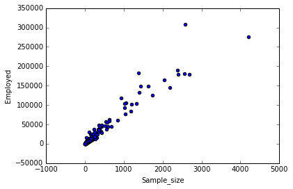

```python
recent_grads.plot(x='Sample_size', y='Employed', kind='scatter')
```

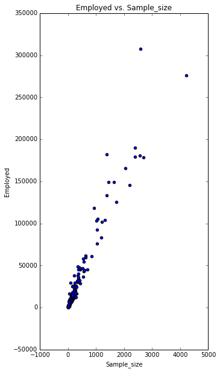

```python
recent_grads.plot(x='Sample_size', y='Employed', kind='scatter', title='Employed vs. Sample_size', figsize=(5,10))
```